STIP Compass data story

# How can STIP Compass data help generate insights in policy publications?

Authors: Jovana Poznan and Daniela Valenzuela

The value of STIP Compass data stems from its breadth, its quality, and — above all — from the diversity of actors who actively use it, ranging from analysts and researchers to policymakers across the STI policy ecosystem. Its relevance is particularly evident in the growing number of policy publications that rely on STIP Compass as a robust evidence base.

This data story presents three key use cases of STIP Compass data in selected policy publications, illustrating each one with specific examples. Together, these cases show the comprehensiveness and quality of the STIP Compass as the most-up-to-date database of STI policies available.

As the dataset continues to expand and evolve, so does the range of analytical possibilities it unlocks for the STI policy community, reinforcing its role as a foundational resource for evidence-based analysis and policy making.

## Analysts increasingly use STIP Compass to extract insights

This data story showcases three main categories of STIP Compass data use in selected policy publications, demonstrating the value of the data in supporting evidence gathering and knowledge creation across the STI policy landscape. Across these publications, STIP Compass data is used in multiple ways — from generating broad insights and analysis within specific thematic areas, to retrieving examples of policy initiatives and supporting comparative analysis of commonly used policy instruments, themes, target groups, and other relevant elements.

During 2025 STIP Compass received over 430,000 views from users across 200 countries and territories, reinforcing its role as a key resource for analysts and policymakers seeking to understand national trends in STI. While many visitors come for brief insights, some engage more intensively with the platform, using its data for in-depth analysis that informs widely recognised reports and flagship publications. Various international organisations extensively use STIP Compass data to extract advanced insights in the STI domain.

## Understanding how selected publications use STIP Compass data

The selection of publications reviewed draws on STIP Compass data in various ways to generate insights. Three main categories of use cases can be identified:

### Generating insights and analysis

Analysing policy initiatives within specific thematic areas to generate insights.

### Retrieving concrete examples of policy initiatives

Drawing country-level policy initiatives from the database to support evidence-based analysis.

### Supporting comparative analysis

Comparing policy instruments, themes, target groups and related elements across countries and regions.

While this is not an exhaustive analysis, the data story shows that most of the reviewed publications primarily use STIP Compass to provide illustrative country examples that support evidence-based analysis. The other two types of use cases — generating thematic insights and supporting comparative analysis — appear slightly less frequently, yet continue to represent important use cases.

## Examples from selected policy publications

The table below summarises the main categories of STIP Compass data use, the policy publications reviewed, and how each uses the data.

[output not shown]

### Generating insights and analysis within specific thematic areas

STIP Compass data supports generation of insights on specific topics by analysing the policy initiatives reported in the database. For example, Chapter 1 of the OECD [*Science, Technology and Innovation Outlook 2025*](https://www.oecd.org/en/publications/2025/10/oecd-science-technology-and-innovation-outlook-2025_bae3698d.html) (“Mobilising science, technology and innovation policies for transformative change”), draws on the analysis of around 400 STIP Compass policy initiatives related to cross-government coherence and co-ordination in support of transformative goals. By leveraging STIP Compass data, it provides general insights on the initiatives’ targets, policy domains and sectors, as well as instruments used, including:

- Many of the initiatives aim to streamline government operations by reducing bureaucracy, consolidating resources, enabling joint priority setting, and harmonising policymaking processes.
- A little over one third of these initiatives include horizontal coordination bodies linking national policy domains, most often in areas such as economic affairs, education, environment, culture, energy, finance, and agriculture.
- Just under half of the initiatives include national strategies that address broad, cross-sector challenges, including energy, climate change and environmental sustainability, socio-economic security and other societal issues such as health and ageing.
- Around half of the strategies examined are accompanied by periodic monitoring or evaluation mechanisms, while a smaller share is linked to targeted tools designed to support their implementation.

In addition, at the European Commission’s DG Research and Innovation (DG RTD), the STIP Compass supports policy work in various ways, helping generate high-level insights and analysis. For instance, data in the STIP Compass database complements the information underpinning the [ERA Country Reports](https://european-research-area.ec.europa.eu/news/explore-national-progress-era-era-country-reports-2024). Additionally, exploring the STIP data is part of the desk research on the design and implementation of ERA-related policies. Furthermore, STIP Compass information supports internal policy work to identify whether countries are prioritising emerging fields such as artificial intelligence (AI) in Science in their strategies, as well as to identify specific investments or policy frameworks in this field, including good practice examples. The STIP Compass database is also used in the analytical work DG RTD carries out during the European Semester cycle, to support the identification of policy trends and relevant R&I policy initiatives at the national level.

### Retrieving concrete examples of policy initiatives from different countries

STIP Compass data is primarily used for retrieving examples of policy initiatives in specific areas, thereby supporting evidence-based analysis. In this use case, the reviewed policy publications draw on concrete examples from the STIP Compass database to illustrate policy actions across different countries. The OECD [*Science, Technology and Innovation Outlook 2025*](https://www.oecd.org/en/publications/2025/10/oecd-science-technology-and-innovation-outlook-2025_bae3698d.html), for instance, retrieves examples from the STIP Compass database to illustrate policy actions undertaken across countries, including measures to increase funding agility, stimulate breakthroughs, and support the entire innovation chain.

Similar use cases are found in policy publications produced by other international organisations. For instance, Mission Innovation’s [*Member Insights 2023-2024*](https://mission-innovation.net/wp-content/uploads/2024/11/Member-Insights-2024_Final.pdf) showcases examples of policy initiatives collected through the 2024 Mission Innovation (MI) - International Energy Agency (IEA) - European Commission (EC) - OECD survey on clean energy innovation policy (see Example 1). MI incorporated relevant findings into the MI Member Insights Report; IEA enhanced its Policies and Measures Database (PAMS) for clean energy technologies; and the OECD updated its STIP Compass portal with new STI policy data supporting the transition to net zero. The MI Member Insights Report 2023–24 summarises the results of the survey, highlighting national strategies and policies guiding research and innovation systems toward energy decarbonisation. By providing a snapshot of the global clean energy innovation landscape, this publication helps policymakers and practitioners better understand emerging trends and make more informed, forward-looking decisions. [*The State of Energy Innovation*](https://www.iea.org/reports/the-state-of-energy-innovation-2025) by the International Energy Agency also draws on data from the 2024 MI-IEA-EC-OECD survey and showcases examples of government policies that support energy technology innovation.

In addition, [*“STI for All”: A Compendium of Good Practices in STI Policy*](https://innovationbridge.info/ibportal/sites/default/files/2025-11/g20_compendium_sti_for_all_2025_b.pdf) - a publication led by the South African G20 Presidency — uses STIP Compass as its main data source to showcase STI policy initiatives from G20 members and guest countries that promote diversity, equity, inclusion and accessibility. Specific emphasis was put on policy initiatives and instruments which relate to the theme of ‘diversity, equity and inclusivity’ and which identify ‘women,’ ‘disadvantaged and excluded groups’ and ‘civil society’ as target groups. Using the STIP Compass as its primary data source, the compendium curates over 1,000 policy initiatives. The study found that several policy initiatives have developed into comprehensive, multi-layered strategies that combine targeted actions with broader systemic reforms to support women in STEM and in research and innovation.

Example 1. Policy initiatives from Australia collected through the 2024 MI-IEA-EC-OECD survey (Member Insights 2023-2024, Mission Innovation)

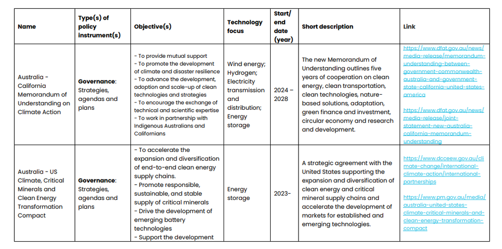

### Supporting comparative analysis

Finally, STIP Compass data is used to support comparative analysis of commonly used policy instruments, themes, target groups and other related elements across different areas.

Several policy publications — including [*Panorama de las Políticas de Desarrollo Productivo en América Latina y el Caribe, 2025: ¿cómo salir de la trampa de baja capacidad para crecer?*](https://www.cepal.org/es/publicaciones/82535-panorama-politicas-desarrollo-productivo-america-latina-caribe-2025-como-salir) by the United Nations Economic Commission for Latin America and the Caribbean — use the STIP Compass database to identify the most commonly used instruments and compare similarities and differences across countries or regions. Similar comparisons can also be made between themes, target groups, budget ranges and more.

The OECD [Science, Technology and Innovation Outlook 2025](https://www.oecd.org/en/publications/2025/10/oecd-science-technology-and-innovation-outlook-2025_bae3698d.html) illustrates this use case by highlighting and comparing examples of policy instruments from the STIP Compass database, such as R&D and innovation funding instruments used by governments, along with their typical ranges across the innovation chain (see Example 2). Governments deploy a wide array of direct and indirect funding instruments to support RDI, yet some are preferred over others depending on whether the objective is to promote (breakthrough) R&D or the demonstration, deployment and diffusion of technologies. The challenge for policymakers lies in striking the right balance between these different types of support.

Example 2. Selected examples of STI policy instruments for public funding of research, development and innovation (the OECD Science, Technology and Innovation Outlook 2025, Chapter 1. Mobilising science, technology and innovation policies for transformative change)

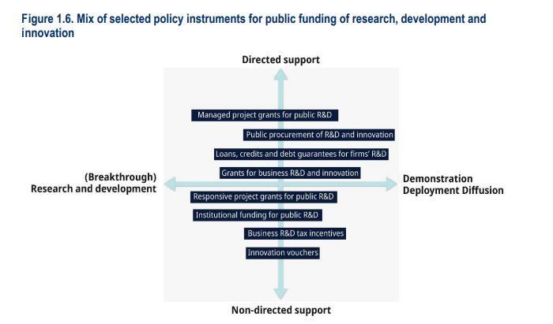

## What do these findings reveal about the use of STIP Compass data?

As a centralised repository for structured and regularly updated STI policy information, STIP Compass provides a wide-ranging evidence base for examining thousands of national policy initiatives organised across more than 50 thematic areas.

The examples reviewed in this data story show that the STIP Compass data can be used to extract both high-level insights and detailed evidence from a consistently structured policy dataset. By examining large sets of initiatives, some policy publications use the data to identify emerging trends across different STI domains. The database also supports the use of concrete country examples, allowing authors to illustrate policy practices and compare them across countries.

Finally, STIP Compass enables systematic comparisons of policy instruments, themes and target groups, helping to reveal structural differences in policy design across countries and regions and strengthening evidence-based STI policy analysis.

These examples illustrate the richness of ways in which STIP Compass data can be used to generate high-quality insights. As the dataset evolves, it will open the door to an expanding array of analytical opportunities for the STI policy community.